# Prediction Interval

Ankit Tyagi

1/5/2019

### Prediction Intervals :-

A prediction interval is an interval within which we expect $y_t$ to lie with a specified probability. Prediction intervals are required to understand how much uncertainity is associated with the point forecast.

If the forecast errors are normally distributed, a 95% prediction interval is given by :-
$$y_{T+h|T} \pm 1.96\ \hat{σ}_{h}$$
where h is forecast horizon.

1. One step Prediction usually have forecast error close to the residuals. In case the method do not have a paramter to estimate they are same.
2. Multi step prediction interval increase as the forecast horizon increase.

The estimate of $σ_{h}$ for different methods are :-

**Mean Forecasts :-** $σ \sqrt{1+1/T}$.

**Naive Forecasts :-** $σ \sqrt{h}$.

**Seasonal Naive Forecasts :-** $σ \sqrt{k +1}$.

**Drift Forecasts :-** $σ \sqrt{h(1+h/T)}$.

Prediction intervals for naive methods on Google Price index data

```r
library(fpp2)
naive(goog200)
```

```
##     Point Forecast    Lo 80    Hi 80    Lo 95    Hi 95
## 201       531.4783 523.5221 539.4344 519.3104 543.6461
## 202       531.4783 520.2266 542.7300 514.2703 548.6862
## 203       531.4783 517.6978 545.2587 510.4029 552.5536
## 204       531.4783 515.5660 547.3906 507.1425 555.8140
## 205       531.4783 513.6878 549.2687 504.2701 558.6865
## 206       531.4783 511.9898 550.9668 501.6732 561.2833
## 207       531.4783 510.4283 552.5282 499.2851 563.6714
## 208       531.4783 508.9749 553.9816 497.0623 565.8942
## 209       531.4783 507.6098 555.3467 494.9747 567.9819
## 210       531.4783 506.3187 556.6378 493.0001 569.9565
```

It is clear that as we are moving up in the forecast horizon the prediction intervals are getting wider. This can also be seen in the graph below.

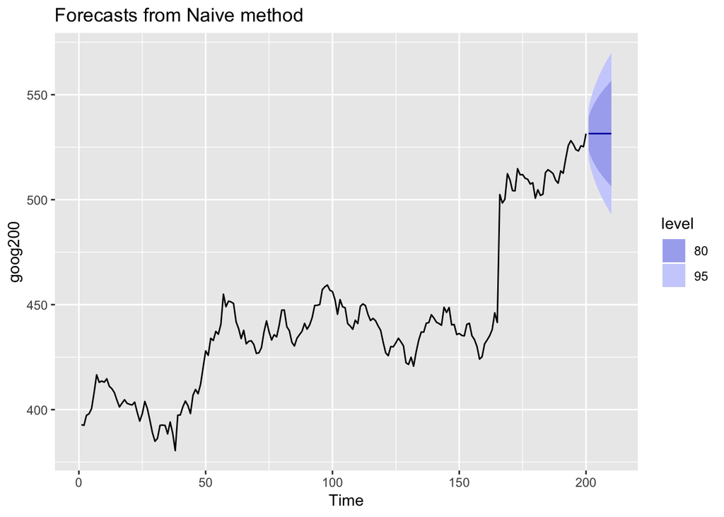

```r
autoplot(naive(goog200))
```

#### Bootstrap Prediction interval :-

If the assumption of normal distribution of forecast error is unreasonable, then we can use bootstrapping that only assumes that the forecast errors are uncorrelated.

Forecast error
$$e_t = y_t - \hat{y}_{t|t-1}$$
$$=> y_t = \hat{y}_{t|t-1} + e_t$$
For $e_t$, we use a sample from the residuals of the past observtions. We can simulate the next observation of a time series using
$$y_{T+1} = \hat{y}_{T+1|T} + e_{T+1}$$
where $e_{T+1}$ is the unknown future error. Assuming future errors are uncorrelated from the past error, we can replace $e_{T+1}$ by sampling from the collection of error we have seen in the past(i.e., residuals). We can repeat this process to obtain
$$y_{T+2} = \hat{y}_{T+2|T+1} + e_{T+2}$$

where $e_{T+1}$ is another draw from the collection of residuals. Doing this repeatedly we obtain many possible futures. Then we can compute prediction intervals by calculating percentiles for each forecast horizon. The result is called a bootstrapped prediction interval.

```r
naive(goog200, bootstrap = TRUE)
```

```
##     Point Forecast    Lo 80    Hi 80    Lo 95    Hi 95
## 201       531.4783 525.6415 537.4795 522.8646 541.0612
## 202       531.4783 523.1914 539.4682 520.0466 545.8946
## 203       531.4783 521.1382 541.1742 516.7319 549.3244
## 204       531.4783 519.1793 542.8619 514.2084 554.1211
## 205       531.4783 517.7973 544.8012 511.6144 578.4890
## 206       531.4783 515.8236 545.8746 509.2861 582.5349
## 207       531.4783 514.4018 547.6179 507.4267 584.5763
## 208       531.4783 512.8937 548.8972 506.0245 586.5646
## 209       531.4783 511.8706 549.9406 504.0695 587.1762
## 210       531.4783 510.5756 551.9785 501.5774 588.5858
```

If a transformation has been used, then the prediction interval should be computed on the transformed scale, and the end points back-transformed to give a prediction interval on the original scale. This approach preserves the probability coverage of the prediction interval, although it will no longer be symmetric around the point forecast.